# Create figures for recognition data

Bria Long

2023-07-26

# Librarites and setup

```r
library(tidyverse)
library(lme4)
library(lmerTest)
library(ggthemes)
library(pander)
library(tidytext) # for plotting
library(knitr) # for html rendering
library(langcog)
library(viridis)
library(xtable)
```

# How does kid and model recognition vary with object part annotations?

## Import recognition data and calculate per sketch

```r
load(file = here::here('data/recognition_data/all_recognition_data_preprocessed.RData'))
```

## Load preprocessed part annotations

```r
load(file = here::here('data/part_annotations_processed/merged_annotations.RData'))
```

## Calculate recognition by sketch for models and kids

```r
# all joined  = joined model / kid recognition
recognition_by_sketch <- all_joined %>%
  ungroup() %>%
  # keep kids of all ages
  rename(category = intended_category) %>%
  group_by(sketch_path, category) %>%
  mutate(num_trials_per_sketch = n()) %>%
  # but need 5 or more trials per sketch for image level analyses
  filter(num_trials_per_sketch > 4) %>%
  dplyr::summarize(model_correct = mean(model_correct_or_not, na.rm=TRUE), kid_correct = mean(correct_or_not, na.rm=TRUE), log_odds = mean(log_odds)) %>%
  filter(!is.na(log_odds)) # filter any sketches that were not recognized by model due to counterbalancing
```

### Sanity check: model vs. kid recognition

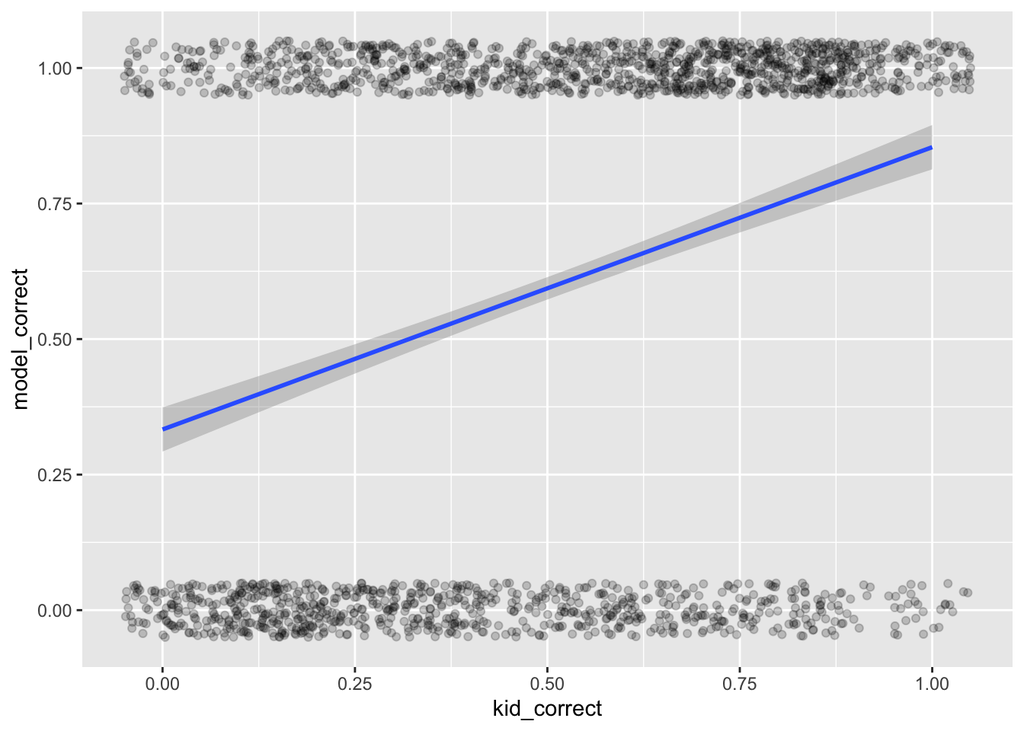

```r
ggplot(recognition_by_sketch, aes(x=kid_correct, y=model_correct)) +
  geom_jitter(width=.05, height=.05, alpha=.2)  +
  geom_smooth(method='lm')
```

```r
cor.test(recognition_by_sketch$kid_correct, recognition_by_sketch$model_correct)
```

```
##
##  Pearson's product-moment correlation
##
## data:  recognition_by_sketch$kid_correct and recognition_by_sketch$model_correct
## t = 14.514, df = 1965, p-value < 2.2e-16
## alternative hypothesis: true correlation is not equal to 0
## 95 percent confidence interval:
##  0.2706869 0.3505378
## sample estimates:
##       cor
## 0.3111614
```

### Descriptives of this set

```r
num_participants = length(unique(all_joined$sessionId))

participant_age <- all_joined %>%
  distinct(sessionId, recognizer_age_numeric) %>%
  summarize(avg_age = mean(recognizer_age_numeric))
```

### Join recognition and annotation data

```r
parts_by_recognition <- d_agree_labels %>%
  mutate(sketch_path = as.factor(str_split_fixed(filename,'.png',2)[,1])) %>%
  group_by(sketch_path, filename, category, age_numeric, gameType) %>%
  summarize(count_parts = length(unique(roi_labelName)), count_unint = sum(sum(roi_labelName == 'unintelligible')>0), count_strokes = length(strokeIndex)) %>%
  mutate(count_parts = count_parts - count_unint) %>%
  left_join(recognition_by_sketch) %>%
  filter(!is.na(kid_correct)) %>%
  filter(!is.na(model_correct))

num_sketches_recognition_included = length(parts_by_recognition$sketch_path)
```

```r
all_joined_with_parts <- all_joined %>%
  left_join(parts_by_recognition %>% select(sketch_path, count_parts)) %>%
  filter(!is.na(count_parts)) # not all sketches had agreement that were recognized
```

# Create recognition dat afigures

```r
by_recognizer_age <- all_joined %>%
  filter(producer_age != 'photo') %>%
  group_by(sessionId, recognizer_age_numeric) %>%
  summarize(avg_correct = mean(correct_or_not), num_trials = n()) %>%
  filter(num_trials > 5) %>%
  group_by(recognizer_age_numeric) %>%
  multi_boot_standard(col = 'avg_correct')

by_each_recognizer <-  all_joined %>%
  group_by(sessionId,recognizer_age_numeric) %>%
  filter(producer_age != 'photo') %>%
  summarize(avg_correct = mean(correct_or_not), num_trials = n()) %>%
  filter(num_trials > 5)
```

### Figure 6A. By recognizer age

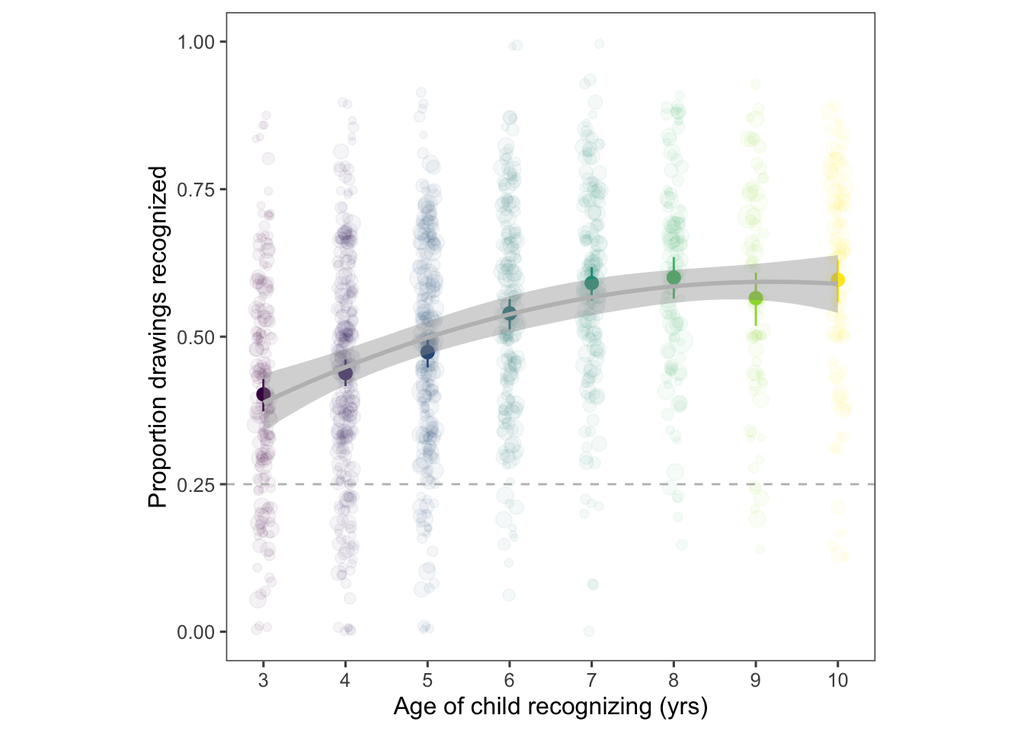

```r
base_size_chosen=12
ggplot(by_recognizer_age,aes(x=recognizer_age_numeric, y=mean, col = recognizer_age_numeric)) +
  theme_few(base_size = base_size_chosen) +
  geom_pointrange(aes(ymin = ci_lower, ymax = ci_upper)) +
  geom_jitter(data = by_each_recognizer, aes(x=recognizer_age_numeric, y=avg_correct, size=num_trials), alpha=.05, width=.1, height=.01) +
  scale_color_viridis(discrete = "FALSE") +
  scale_size_area(max_size = 5) +
  ylab('Proportion drawings recognized') +
  ylim(0, 1) +
  geom_hline(yintercept = .25, linetype = 'dashed', color='grey')  +
  geom_smooth(color = 'grey', span=5) +
  xlab('Age of child recognizing (yrs)') +
  theme(legend.position='none', aspect.ratio = 1) +
  # labs(title='Drawing recognition by age') +
  scale_x_continuous(breaks = seq(3,10,1))
```

```r
ggsave(here::here('data/figures_out/Figure6A_drawing_recognition_by_age.pdf'),width=3, height=3, units='in', useDingbats=FALSE)

write_csv(by_recognizer_age, path = here::here('data/figures_csvs/Figure6A_drawing_recognition_by_age.csv'))
```

### Figure 6B. By classifier evidence

```r
correct_by_distinct <- all_joined %>%
  filter(!is.na(distinct_index)) %>% # filter any sketches that were not recognized by model due to counterbalancing
  group_by(recognizer_age_numeric, distinct_index) %>%
  multi_boot_standard(col = 'correct_or_not')
```

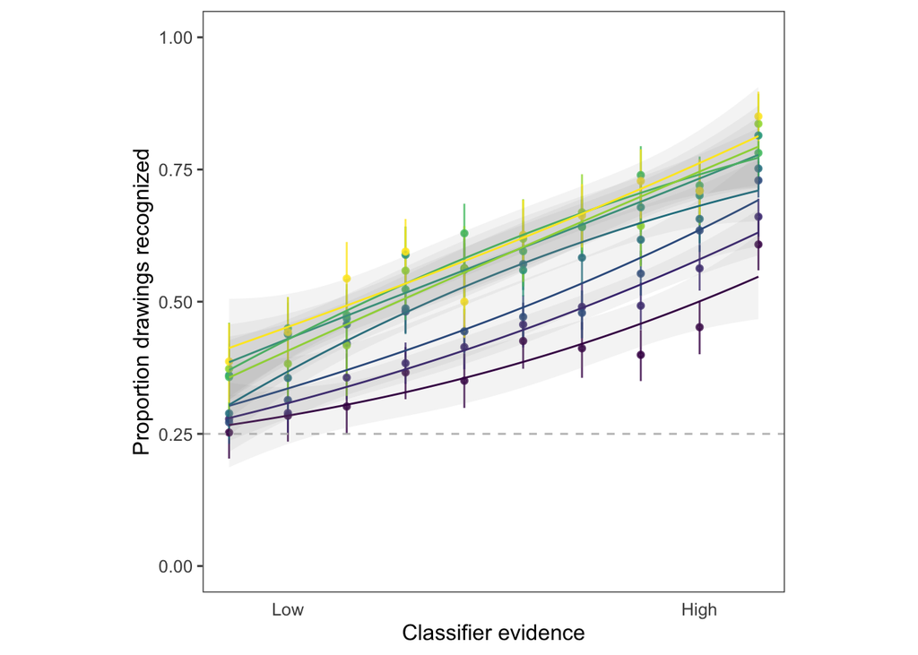

```r
ggplot(correct_by_distinct, aes(x=distinct_index, y=mean, col=as.factor(recognizer_age_numeric))) +
  geom_pointrange(aes(ymin = ci_lower, ymax = ci_upper), alpha=.8, size=.2) +
  geom_smooth(alpha=.1,  span=5, size=.5) +
  theme_few(base_size = 12) +
  xlab('Classifier evidence') +
  ylab('Proportion drawings recognized') +
  theme(legend.position='none') +
  scale_color_viridis(discrete=TRUE) +
  scale_x_continuous(
    breaks=c(2,9),
    labels=c(' Low ',' High ')
        ) +
  theme(axis.ticks.x=element_blank(), aspect.ratio=1) +
  geom_hline(yintercept=.25, linetype='dashed',color='grey') +
  ylim(0,1)
```

```r
ggsave(here::here('data/figures_out/Figure6b_recog_by_classifier.pdf'), width=3, height=3, units='in', useDingbats=FALSE)

write_csv(correct_by_distinct, path = here::here('data/figures_csvs/Figure6b_recog_by_classifier.csv'))
```

# Join recognition and annotation data

```r
parts_by_recognition <- d_agree_labels %>%
  mutate(sketch_path = as.factor(str_split_fixed(filename,'.png',2)[,1])) %>%
  group_by(sketch_path, filename, category, age_numeric, gameType) %>%
  summarize(count_parts = length(unique(roi_labelName)), count_unint = sum(sum(roi_labelName == 'unintelligible')>0), count_strokes = length(strokeIndex)) %>%
  mutate(count_parts = count_parts - count_unint) %>%
  left_join(recognition_by_sketch) %>%
  filter(!is.na(kid_correct)) %>%
  filter(!is.na(model_correct))

num_sketches_recognition_included = length(parts_by_recognition$sketch_path)
```

## Appendix figure: recognition by categorys

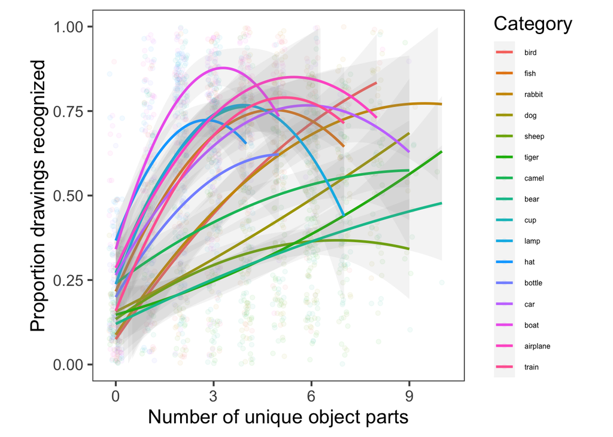

```r
parts_by_recognition <- parts_by_recognition %>%
  mutate(count_parts_bin = ntile(count_parts,10))

ggplot(data=parts_by_recognition, aes(y=kid_correct,  x=count_parts, color=category, group=category)) +
  geom_jitter(width=.2, height=.05, alpha=.05) +
  theme_few(base_size=16) +
  geom_smooth(span=10, alpha=.1) +
  ylim(0,1) +
  ylab('Proportion drawings recognized') +
  xlab('Number of unique object parts') +
  theme(aspect.ratio=1, legend.position='right',legend.text=element_text(size=6)) +
  scale_x_continuous(breaks=c(0,3,6,9)) +
  guides(color=guide_legend(title="Category", ncol=1))
```

```r
ggsave(here::here('data/figures_out/Appendix_B4_parts_by_recognition_panel.pdf'), width=6, height=6)

write_csv(parts_by_recognition, file = here::here('data/figures_csvs/Appendix_B4_parts_by_recognition_panel.csv'))
```

## Not in paper, but same trends with CIs and binned parts

```r
parts_by_category <- all_joined_with_parts %>%
  ungroup() %>%
  mutate(part_index = ntile(count_parts,10)) %>%
  group_by(category, part_index) %>%
  multi_boot_standard(col='correct_or_not')
```

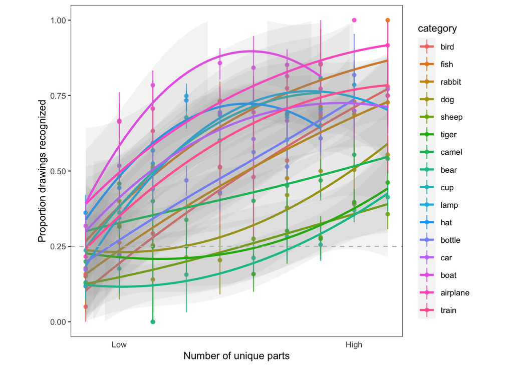

```r
 ggplot(parts_by_category, aes(x=part_index, y=mean, col=category, group=category)) +
  geom_pointrange(aes(ymin = ci_lower, ymax = ci_upper), alpha=.8, size=.2) +
  geom_smooth(alpha=.1,  span=4 ) +
  # facet_wrap(~category, nrow=2) +
  theme_few(base_size = 10) +
  xlab('Number of unique parts') +
  ylab('Proportion drawings recognized') +
  theme(legend.position='right') +
  # scale_color_viridis(discrete=TRUE) +
  scale_x_continuous(
    breaks=c(2,9),
    labels=c(' Low ',' High ')
        ) +
  theme(axis.ticks.x=element_blank(), aspect.ratio=1) +
  geom_hline(yintercept=.25, linetype='dashed',color='grey') +
  ylim(0,1)
```

## Calculate parts x recognizer age

```r
parts_by_age <- all_joined_with_parts %>%
  mutate(part_index = ntile(count_parts,10)) %>%
  group_by(recognizer_age_numeric, part_index) %>%
  multi_boot_standard(col='correct_or_not')
```

```r
 parts_by_age_plot <- ggplot(parts_by_age, aes(x=part_index, y=mean, col=as.factor(recognizer_age_numeric))) +
  geom_pointrange(aes(ymin = ci_lower, ymax = ci_upper), alpha=.8, size=.2) +
  geom_smooth(alpha=.1,  span=4, size=.25) +
  theme_few(base_size = 12) +
  xlab('Number of unique object parts') +
  ylab('Proportion drawings recognized') +
  theme(legend.position='none') +
  scale_color_viridis(discrete=TRUE) +
  scale_x_continuous(
    breaks=c(2,9),
    labels=c(' Low ',' High ')
        ) +
  theme(axis.ticks.x=element_blank(), aspect.ratio=1) +
  geom_hline(yintercept=.25, linetype='dashed',color='grey') +
  ylim(0,1)


ggsave(here::here('data/figures_out/Figure6C_kid_recognition_by_unique_parts.pdf'), width=3, height=3, units='in',useDingbats = FALSE)

write_csv(parts_by_age, path = here::here('data/figures_csvs/Figure6C_kid_recognition_by_unique_parts.csv'))
```

# Inferential stats: Does children’s ability to use parts during recognition change with age?

## Create data structure

```r
### Unit of anlaysis -- trial-level recognition data, sessionId = recognizer ID

all_joined_with_parts <- all_joined %>%
  left_join(parts_by_recognition %>% select(sketch_path, count_parts)) %>%
  mutate(count_parts_scaled= scale(count_parts), age_scaled = scale(recognizer_age_numeric)) %>%
  filter(!is.na(count_parts)) # not all drawings had agreement
```

## Model recognition data with 2nd order polynomial andcount parts

```r
model_glmer <- glmer(correct_or_not ~ poly(count_parts_scaled,2)*age_scaled + (count_parts_scaled|intended_category) + (1|sessionId),  data = all_joined_with_parts, family='binomial')

summary(model_glmer)
```

```
## Generalized linear mixed model fit by maximum likelihood (Laplace
##   Approximation) [glmerMod]
##  Family: binomial  ( logit )
## Formula:
## correct_or_not ~ poly(count_parts_scaled, 2) * age_scaled + (count_parts_scaled |
##     intended_category) + (1 | sessionId)
##    Data: all_joined_with_parts
##
##      AIC      BIC   logLik deviance df.resid
##  30803.9  30885.4 -15392.0  30783.9    25560
##
## Scaled residuals:
##     Min      1Q  Median      3Q     Max
## -4.1477 -0.7906  0.3340  0.7721  4.6485
##
## Random effects:
##  Groups            Name               Variance Std.Dev. Corr
##  sessionId         (Intercept)        0.25394  0.5039
##  intended_category (Intercept)        0.77445  0.8800
##                    count_parts_scaled 0.04152  0.2038   0.61
## Number of obs: 25570, groups:  sessionId, 1783; intended_category, 16
##
## Fixed effects:
##                                          Estimate Std. Error z value Pr(>|z|)
## (Intercept)                               0.04714    0.20215   0.233    0.816
## poly(count_parts_scaled, 2)1            129.39202    6.09724  21.221  < 2e-16
## poly(count_parts_scaled, 2)2            -34.98447    2.94444 -11.882  < 2e-16
## age_scaled                                0.34004    0.01995  17.046  < 2e-16
## poly(count_parts_scaled, 2)1:age_scaled  12.69677    2.53725   5.004 5.61e-07
## poly(count_parts_scaled, 2)2:age_scaled  -8.94773    2.21309  -4.043 5.28e-05
##
## (Intercept)
## poly(count_parts_scaled, 2)1            ***
## poly(count_parts_scaled, 2)2            ***
## age_scaled                              ***
## poly(count_parts_scaled, 2)1:age_scaled ***
## poly(count_parts_scaled, 2)2:age_scaled ***
## ---
## Signif. codes:  0 '***' 0.001 '**' 0.01 '*' 0.05 '.' 0.1 ' ' 1
##
## Correlation of Fixed Effects:
##             (Intr) pl(__,2)1 pl(__,2)2 ag_scl p(__,2)1:
## ply(c__,2)1  0.423
## ply(c__,2)2  0.002  0.044
## age_scaled   0.000  0.016    -0.013
## pl(__,2)1:_  0.027  0.073     0.050    -0.003
## pl(__,2)2:_ -0.012 -0.013     0.006    -0.021 -0.047
```

```r
cis_parts = confint(model_glmer, method='Wald')
```

```r
summary_model <- summary(model_glmer)

summary_table_complete <- cbind(Estimate = sprintf("%.3f",round(summary_model$coefficients[, "Estimate"],3)),
                                `Std. Error` = sprintf("%.3f",round(summary_model$coefficients[, "Std. Error"],3)),
                                `z value` = sprintf("%.3f",round(summary_model$coefficients[, "z value"],3)),
                                `Pr(>|z|)` = format.pval(summary_model$coefficients[, "Pr(>|z|)"],eps=0.0001,scientific = FALSE, digits=2),
                                 `2.5 % CI` = sprintf("%.3f",round(cis_parts[5:10, 1],3)),
                                `97.5 % CI` = sprintf("%.3f",round(cis_parts[5:10, 2],3)))

rownames(summary_table_complete) = c('Intercept','Number of unique parts ', 'Number of unique parts^2',  "Recognizer Age","Number of unique parts x Recognizer Age", "Number of unique parts^2 x Recognizer Age")
```

```r
xtable(summary_table_complete, digits=3, caption= "Modeling children's drawing recognition by part inclusion. All model coefficients from a generalized, linear mixed effect model predicting how well children could recognize drawings of visual concepts as a function of their own age (Age; recognizer age) and the number of unique parts included in each drawing.")
```

[output not shown]

# Appendix: Part inclusion/emphasis by binned model classification per category

```r
load(file = here::here('data/part_annotations_processed/part_emphasis.RData'))
```

```r
binned_model_recognition_by_sketch_for_emphasis <-  recognition_by_sketch %>%
  ungroup() %>%
  group_by(category) %>% # construct bins WITHIN categories
  mutate(model_correct_bin = ntile(log_odds,4))

binned_count_recognition_by_sketch <- binned_model_recognition_by_sketch_for_emphasis %>%
  group_by(category, model_correct_bin) %>%
  summarize(count_images_bin = length(unique(sketch_path)))
```

```r
part_emphasis_recognition_binned <- part_emphasis_all %>%
  mutate(sketch_path = as.factor(str_split_fixed(filename,'.png',2)[,1])) %>%
  right_join(binned_model_recognition_by_sketch_for_emphasis) %>%
  right_join(binned_count_recognition_by_sketch)
```

```r
# get emphasized parts without recognition
top_parts_emphasis <- part_emphasis_all %>%
  group_by(category, roi_labelName) %>%
  filter(!roi_labelName %in% c('body','head')) %>%
  summarize(avg_emphasis = mean(emphasis), count_drawings = n()) %>%
  group_by(category) %>%
  slice_max(n=5, order_by=count_drawings)
#
```

```r
part_emphasis_top_4_by_model_bin <- part_emphasis_recognition_binned %>%
  right_join(top_parts_emphasis %>% select(category, roi_labelName)) %>%
  group_by(category, model_correct_bin, roi_labelName,count_images_bin) %>%
  dplyr::summarize(avg_emphasis = mean(emphasis), count_drawings_with_part = length(unique(filename))) %>%
  mutate(prop_drawings = count_drawings_with_part / count_images_bin)
```

```r
# part_names = unique(part_emphasis_top_4_by_model_bin$roi_labelName)
part_emphasis_top_4_by_model_bin <- part_emphasis_top_4_by_model_bin %>%
  mutate(label = as.factor(roi_labelName), levels =  unique(roi_labelName))
```

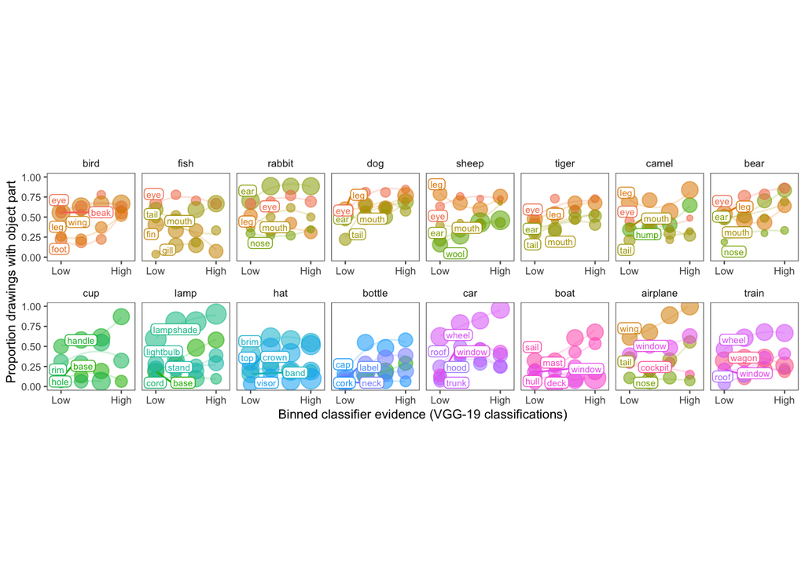

```r
ggplot(data = part_emphasis_top_4_by_model_bin, aes(x=model_correct_bin, y=prop_drawings, col=label)) +
  geom_point(aes(size = avg_emphasis, alpha=.2)) +
  # geom_linerange(aes(ymin = ci_lower, ymax = ci_upper), alpha=.5) +
  facet_wrap(~category, nrow=1) +
  theme_few(base_size=8) +
  # geom_line() +
  geom_line(stat='smooth',alpha=.2, span=10) +
  # stat_smooth(geom="line", alpha=0.3, size=.5, span=10) +
  # geom_smooth(aes(group=roi_labelName), span=10, alpha=.01) +
  # scale_color_viridis(option = 'F', discrete=TRUE) +
  ylab('Proportion drawings with object part') +
  xlab('Binned classifier evidence (VGG-19 classifications)') +
  theme(legend.position = 'none', aspect.ratio = 1)  +
  ylim(0,1) +
  facet_wrap(~category, nrow=2, scales = 'free_x') +
  scale_x_continuous(
    limits=c(.5,4.5),
    breaks=c(1,4),
    labels=c(' Low ',' High ')
        ) +
  ggrepel::geom_label_repel(data =part_emphasis_top_4_by_model_bin %>% filter(model_correct_bin==1), aes(label = roi_labelName), max.overlaps=10, size=2, box.padding=.1, label.padding=.1)
```

```r
ggsave(here::here('data/figures_out/Appendix_A9_part_emphasis_by_model_bin.pdf'),units = 'in', height = 3, width = 8)


write_csv(part_emphasis_top_4_by_model_bin, path = here::here('data/figures_csvs/Appendix_A9_part_emphasis_by_model_bin.csv'))
```

**R version 4.3.1 (2023-06-16)**

**Platform:** x86_64-apple-darwin20 (64-bit)

**locale:** en_US.UTF-8||en_US.UTF-8||en_US.UTF-8||C||en_US.UTF-8||en_US.UTF-8

**attached base packages:** *stats*, *graphics*, *grDevices*, *utils*, *datasets*, *methods* and *base*

**other attached packages:** *xtable(v.1.8-4)*, *viridis(v.0.6.4)*, *viridisLite(v.0.4.2)*, *langcog(v.0.1.9001)*, *knitr(v.1.43)*, *tidytext(v.0.4.1)*, *pander(v.0.6.5)*, *ggthemes(v.4.2.4)*, *lmerTest(v.3.1-3)*, *lme4(v.1.1-34)*, *Matrix(v.1.6-1)*, *lubridate(v.1.9.2)*, *forcats(v.1.0.0)*, *stringr(v.1.5.0)*, *dplyr(v.1.1.2)*, *purrr(v.1.0.2)*, *readr(v.2.1.4)*, *tidyr(v.1.3.0)*, *tibble(v.3.2.1)*, *ggplot2(v.3.4.3)* and *tidyverse(v.2.0.0)*

**loaded via a namespace (and not attached):** *tidyselect(v.1.2.0)*, *farver(v.2.1.1)*, *fastmap(v.1.1.1)*, *lazyeval(v.0.2.2)*, *janeaustenr(v.1.0.0)*, *digest(v.0.6.33)*, *rpart(v.4.1.19)*, *timechange(v.0.2.0)*, *lifecycle(v.1.0.3)*, *cluster(v.2.1.4)*, *tokenizers(v.0.3.0)*, *magrittr(v.2.0.3)*, *compiler(v.4.3.1)*, *rlang(v.1.1.1)*, *Hmisc(v.5.1-1)*, *sass(v.0.4.7)*, *tools(v.4.3.1)*, *utf8(v.1.2.3)*, *yaml(v.2.3.7)*, *data.table(v.1.14.8)*, *labeling(v.0.4.2)*, *htmlwidgets(v.1.6.2)*, *bit(v.4.0.5)*, *here(v.1.0.1)*, *withr(v.2.5.0)*, *foreign(v.0.8-84)*, *numDeriv(v.2016.8-1.1)*, *nnet(v.7.3-19)*, *grid(v.4.3.1)*, *fansi(v.1.0.4)*, *colorspace(v.2.1-0)*, *scales(v.1.2.1)*, *MASS(v.7.3-60)*, *cli(v.3.6.1)*, *crayon(v.1.5.2)*, *rmarkdown(v.2.24)*, *ragg(v.1.2.5)*, *generics(v.0.1.3)*, *rstudioapi(v.0.15.0)*, *tzdb(v.0.4.0)*, *minqa(v.1.2.5)*, *cachem(v.1.0.8)*, *splines(v.4.3.1)*, *parallel(v.4.3.1)*, *base64enc(v.0.1-3)*, *vctrs(v.0.6.3)*, *boot(v.1.3-28.1)*, *jsonlite(v.1.8.7)*, *hms(v.1.1.3)*, *ggrepel(v.0.9.3)*, *bit64(v.4.0.5)*, *Formula(v.1.2-5)*, *htmlTable(v.2.4.1)*, *systemfonts(v.1.0.4)*, *jquerylib(v.0.1.4)*, *glue(v.1.6.2)*, *nloptr(v.2.0.3)*, *stringi(v.1.7.12)*, *gtable(v.0.3.4)*, *munsell(v.0.5.0)*, *pillar(v.1.9.0)*, *htmltools(v.0.5.6)*, *R6(v.2.5.1)*, *textshaping(v.0.3.6)*, *rprojroot(v.2.0.3)*, *vroom(v.1.6.3)*, *evaluate(v.0.21)*, *lattice(v.0.21-8)*, *highr(v.0.10)*, *backports(v.1.4.1)*, *SnowballC(v.0.7.1)*, *bslib(v.0.5.1)*, *Rcpp(v.1.0.11)*, *gridExtra(v.2.3)*, *nlme(v.3.1-162)*, *checkmate(v.2.2.0)*, *mgcv(v.1.8-42)*, *xfun(v.0.40)* and *pkgconfig(v.2.0.3)*